# Project - Thera Bank

Juan Esteban Venegas

### 1. Project Objectives

The objective is to build a model for the marketing department of the Thera Bank to identify the potential customers who have a higher probability of purchasing a loan. This will increase the success ratio while at the same time reduce the cost of the campaign.

### 2. Exploratory Data Analysis – Step by step approach

#### 2.1 Environment Set up and Data Import

##### 2.1.1 Call necessary Packages and Invoke Libraries

```r
pacman::p_load(ggplot2, data.table, scales, corrplot, car, psych, broom, readxl, glmnet, NbClust, cluster, caret, factoextra, rpart.plot, rpart, randomForest)
```

##### 2.1.2 Set up working Directory

```r
setwd('C:/Users/Juan Esteban Venegas/Desktop/Machine Learning Learning/Greatlearning/Greatlearning_projects/Project_4_Thera_Bank')
getwd()
```

```
## [1] "C:/Users/Juan Esteban Venegas/Desktop/Machine Learning Learning/Greatlearning/Greatlearning_projects/Project_4_Thera_Bank"
```

##### 2.1.3 Import and Read the Dataset

Dataset consists of a sheet with information and the data base. The sheet with information contains a brief description on each variable which is shown below:

```r
ReadMe <- as.data.table(read_xlsx(paste0(getwd(),'/Thera Bank_Personal_Loan_Modelling-dataset-1.xlsx'), sheet = 'ReadMe'))
names(ReadMe) <- c('Variable', 'Description')
ReadMe <- ReadMe[!is.na(Variable)]
print(ReadMe)
```

```
##                       Variable
##  1:                         ID
##  2:                        Age
##  3:                 Experience
##  4:                     Income
##  5:                    ZIPCode
##  6:                     Family
##  7:                      CCAvg
##  8:                  Education
##  9:                   Mortgage
## 10:              Personal Loan
## 11:         Securities Account
## 12:                 CD Account
## 13:                     Online
## 14:                 CreditCard
```

[output cut: 17 more lines]

Some variables need to be transformed from numeric to factor. In addition to this, additional validations must be made to define future data preparation steps.

```r
Thera_Bank <- as.data.table(read_xlsx(paste0(getwd(),'/Thera Bank_Personal_Loan_Modelling-dataset-1.xlsx'), sheet = 'Bank_Personal_Loan_Modelling'))
names(Thera_Bank) <- gsub("\\.","",make.names(gsub("(?<=[\\s])\\s*|^\\s+|\\s+|\\.$", "_", names(Thera_Bank), perl=TRUE)))
str(Thera_Bank)
```

```
## Classes 'data.table' and 'data.frame':   5000 obs. of  14 variables:
##  $ ID                 : num  1 2 3 4 5 6 7 8 9 10 ...
##  $ Age_in_years       : num  25 45 39 35 35 37 53 50 35 34 ...
##  $ Experience_in_years: num  1 19 15 9 8 13 27 24 10 9 ...
##  $ Income_in_Kmonth   : num  49 34 11 100 45 29 72 22 81 180 ...
##  $ ZIP_Code           : num  91107 90089 94720 94112 91330 ...
##  $ Family_members     : num  4 3 1 1 4 4 2 1 3 1 ...
##  $ CCAvg              : num  1.6 1.5 1 2.7 1 0.4 1.5 0.3 0.6 8.9 ...
##  $ Education          : num  1 1 1 2 2 2 2 3 2 3 ...
##  $ Mortgage           : num  0 0 0 0 0 155 0 0 104 0 ...
##  $ Personal_Loan      : num  0 0 0 0 0 0 0 0 0 1 ...
##  $ Securities_Account : num  1 1 0 0 0 0 0 0 0 0 ...
##  $ CD_Account         : num  0 0 0 0 0 0 0 0 0 0 ...
##  $ Online             : num  0 0 0 0 0 1 1 0 1 0 ...
##  $ CreditCard         : num  0 0 0 0 1 0 0 1 0 0 ...
##  - attr(*, ".internal.selfref")=<externalptr>
```

```r
summary(Thera_Bank)
```

```
##        ID        Age_in_years   Experience_in_years Income_in_Kmonth
##  Min.   :   1   Min.   :23.00   Min.   :-3.0        Min.   :  8.00
##  1st Qu.:1251   1st Qu.:35.00   1st Qu.:10.0        1st Qu.: 39.00
##  Median :2500   Median :45.00   Median :20.0        Median : 64.00
##  Mean   :2500   Mean   :45.34   Mean   :20.1        Mean   : 73.77
##  3rd Qu.:3750   3rd Qu.:55.00   3rd Qu.:30.0        3rd Qu.: 98.00
##  Max.   :5000   Max.   :67.00   Max.   :43.0        Max.   :224.00
##
##     ZIP_Code     Family_members      CCAvg          Education
##  Min.   : 9307   Min.   :1.000   Min.   : 0.000   Min.   :1.000
##  1st Qu.:91911   1st Qu.:1.000   1st Qu.: 0.700   1st Qu.:1.000
##  Median :93437   Median :2.000   Median : 1.500   Median :2.000
##  Mean   :93153   Mean   :2.397   Mean   : 1.938   Mean   :1.881
##  3rd Qu.:94608   3rd Qu.:3.000   3rd Qu.: 2.500   3rd Qu.:3.000
##  Max.   :96651   Max.   :4.000   Max.   :10.000   Max.   :3.000
##                  NA's   :18
##     Mortgage     Personal_Loan   Securities_Account   CD_Account
##  Min.   :  0.0   Min.   :0.000   Min.   :0.0000     Min.   :0.0000
##  1st Qu.:  0.0   1st Qu.:0.000   1st Qu.:0.0000     1st Qu.:0.0000
##  Median :  0.0   Median :0.000   Median :0.0000     Median :0.0000
##  Mean   : 56.5   Mean   :0.096   Mean   :0.1044     Mean   :0.0604
##  3rd Qu.:101.0   3rd Qu.:0.000   3rd Qu.:0.0000     3rd Qu.:0.0000
##  Max.   :635.0   Max.   :1.000   Max.   :1.0000     Max.   :1.0000
##
##      Online         CreditCard
##  Min.   :0.0000   Min.   :0.000
##  1st Qu.:0.0000   1st Qu.:0.000
##  Median :1.0000   Median :0.000
##  Mean   :0.5968   Mean   :0.294
##  3rd Qu.:1.0000   3rd Qu.:1.000
##  Max.   :1.0000   Max.   :1.000
##
```

Variable Family_members has null values. Variable Experience_in_years has negative values. These two issues need to be addressed before creating the model.

##### 2.1.4 Data Transformation

- Variables to factor:

```r
Thera_Bank[,c('Education', 'Personal_Loan', 'Securities_Account', 'CD_Account', 'Online', 'CreditCard', 'ZIP_Code')] <- lapply(Thera_Bank[,c('Education', 'Personal_Loan', 'Securities_Account', 'CD_Account', 'Online', 'CreditCard', 'ZIP_Code')] , factor)
```

- Missing values: Before deciding what to do with missing values it is useful to view the distribution of numeric variables and if they have outliers.

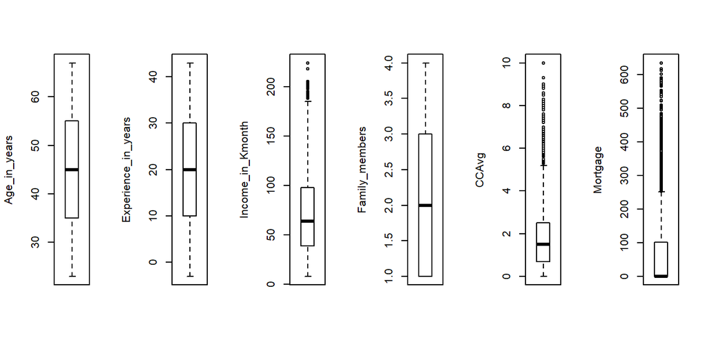

```r
numeric_variables <- names(which(sapply(Thera_Bank,is.numeric) & !(names(Thera_Bank) %in% c('ID', 'ZIP_Code'))))
par(mfrow = c(1,length(numeric_variables)))
outliers_list <- list()
  for(i in 1:length(numeric_variables)){
    plot <- boxplot(Thera_Bank[,numeric_variables[i], with = FALSE], ylab = numeric_variables[i])
    outliers_list[[numeric_variables[i]]] <- Thera_Bank[eval(parse(text = numeric_variables[i])) %in% plot$out]
    outliers_list[[numeric_variables[i]]]$outlier <- numeric_variables[i]
    }
```

```r
table(Thera_Bank$Family_members)
```

```
##
##    1    2    3    4
## 1464 1292 1009 1217
```

Because of this, instead of removing the ID’s with missing values it will be easier to input them using the median.

```r
Thera_Bank[, Family_members := ifelse(is.na(Family_members), median(Thera_Bank$Family_members, na.rm = TRUE), Family_members)]
sum(is.na(Thera_Bank))
```

```
## [1] 0
```

- Negative Experience: Beofre deciding what to do with negative Experience_in_years values it is important to understand this variable better.

```r
cor_matrix <- cor(Thera_Bank[,numeric_variables, with = FALSE])
cor_matrix
```

```
##                     Age_in_years Experience_in_years Income_in_Kmonth
## Age_in_years          1.00000000          0.99421486      -0.05526862
## Experience_in_years   0.99421486          1.00000000      -0.04657418
## Income_in_Kmonth     -0.05526862         -0.04657418       1.00000000
## Family_members       -0.04542979         -0.05158364      -0.15736366
## CCAvg                -0.05201218         -0.05007651       0.64598367
## Mortgage             -0.01253859         -0.01058155       0.20680623
##                     Family_members       CCAvg    Mortgage
## Age_in_years           -0.04542979 -0.05201218 -0.01253859
## Experience_in_years    -0.05158364 -0.05007651 -0.01058155
## Income_in_Kmonth       -0.15736366  0.64598367  0.20680623
## Family_members          1.00000000 -0.11031420 -0.02022110
## CCAvg                  -0.11031420  1.00000000  0.10990472
## Mortgage               -0.02022110  0.10990472  1.00000000
```

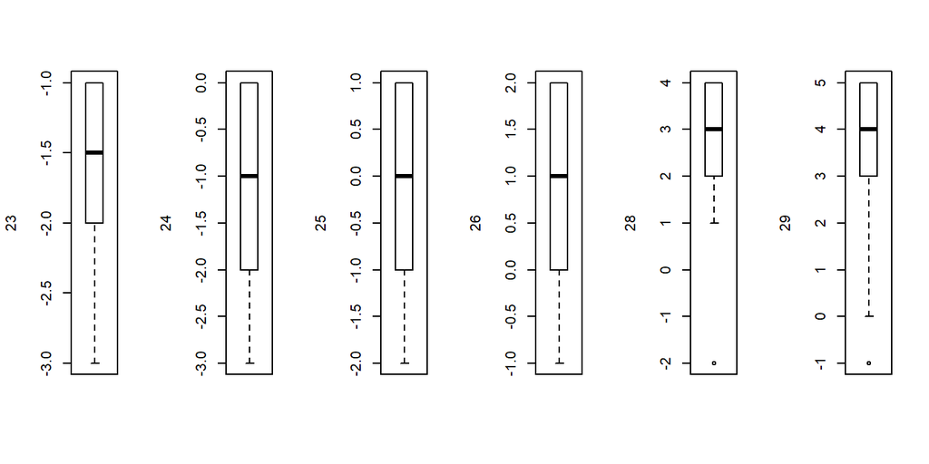

```r
neg_exp_age <- unique(Thera_Bank[Experience_in_years <0, .(Age_in_years)][order(Age_in_years)])
par(mfrow = c(1,nrow(neg_exp_age)))
  for(i in 1:nrow(neg_exp_age)){
    plot <- boxplot(Thera_Bank[Age_in_years == as.numeric(neg_exp_age[i,1])]$Experience_in_years, ylab = neg_exp_age[i,1])
    }
```

Age and Experience have a very high positive correlation so it is important to see how age behaves with negative experience. Negative experience values have ages

| Age_in_years |
| --- |
| 23 |
| 24 |
| 25 |
| 26 |
| 28 |
| 29 |

values.

Observations with age <= 25 have negative median or 0 for experience which could mean that some of these people are studying and these negative years could be interpreted as years left to graduate. However, there is no information to deduce this so people under 25 with negative experience will be assign a 0 for their experience.

People with experience bellow 0 and age >= 26 will be assigned a median value for experience.

```r
median_experience <- Thera_Bank[,.(med_exp = median(Experience_in_years, na.rm = TRUE)), by = .(Age_in_years)]
Thera_Bank <- median_experience[Thera_Bank, on = c('Age_in_years')]
Thera_Bank <- Thera_Bank[, Experience_in_years := ifelse(Experience_in_years < 0 & Age_in_years <= 25, 0, ifelse(Experience_in_years <0, med_exp, Experience_in_years))][, med_exp := NULL]
```

- One hot encoding: One hot encoding will be performed to be able to easily manage categorical variables.

```r
dmy <- dummyVars(" ~ .", data = Thera_Bank[,!c("ZIP_Code","Personal_Loan", "ID")])
Thera_Bank_ohe <- data.frame(predict(dmy, newdata = Thera_Bank))
Thera_Bank_ohe <- cbind(Thera_Bank[,.(Personal_Loan)], Thera_Bank_ohe)
str(Thera_Bank_ohe)
```

```
## Classes 'data.table' and 'data.frame':   5000 obs. of  18 variables:
##  $ Personal_Loan       : Factor w/ 2 levels "0","1": 1 1 1 1 1 1 1 1 1 2 ...
##  $ Age_in_years        : num  25 45 39 35 35 37 53 50 35 34 ...
##  $ Experience_in_years : num  1 19 15 9 8 13 27 24 10 9 ...
##  $ Income_in_Kmonth    : num  49 34 11 100 45 29 72 22 81 180 ...
##  $ Family_members      : num  4 3 1 1 4 4 2 1 3 1 ...
##  $ CCAvg               : num  1.6 1.5 1 2.7 1 0.4 1.5 0.3 0.6 8.9 ...
##  $ Education.1         : num  1 1 1 0 0 0 0 0 0 0 ...
##  $ Education.2         : num  0 0 0 1 1 1 1 0 1 0 ...
##  $ Education.3         : num  0 0 0 0 0 0 0 1 0 1 ...
##  $ Mortgage            : num  0 0 0 0 0 155 0 0 104 0 ...
##  $ Securities_Account.0: num  0 0 1 1 1 1 1 1 1 1 ...
##  $ Securities_Account.1: num  1 1 0 0 0 0 0 0 0 0 ...
##  $ CD_Account.0        : num  1 1 1 1 1 1 1 1 1 1 ...
##  $ CD_Account.1        : num  0 0 0 0 0 0 0 0 0 0 ...
##  $ Online.0            : num  1 1 1 1 1 0 0 1 0 1 ...
##  $ Online.1            : num  0 0 0 0 0 1 1 0 1 0 ...
##  $ CreditCard.0        : num  1 1 1 1 0 1 1 0 1 1 ...
##  $ CreditCard.1        : num  0 0 0 0 1 0 0 1 0 0 ...
##  - attr(*, ".internal.selfref")=<externalptr>
```

#### 2.3 Univariate Analysis

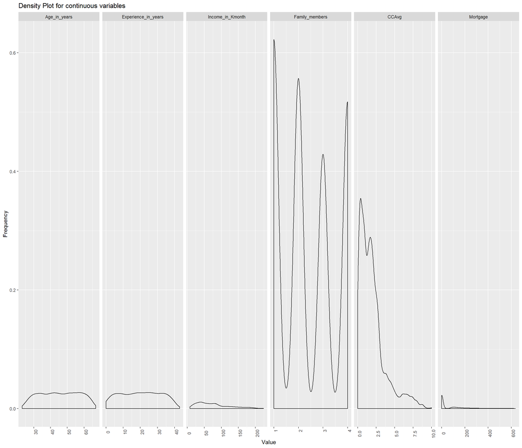

```r
ggplot(melt(Thera_Bank[,c(numeric_variables,'ID'), with = FALSE][], id.vars = 'ID', variable.name = 'Variable', value.name = 'Value'), aes(x = Value)) + geom_density() + facet_grid(.~Variable, scales = 'free') + labs(title = 'Density Plot for continuous variables', x = 'Value', y = 'Frequency') + theme(axis.text.x = element_text(angle = 90))
```

Age and experience seem to have similar distributions with the sample spread evenly. Income, CCAvg and Mortgage seem to be right skewed.

#### 2.4 Bi-Variate Analysis

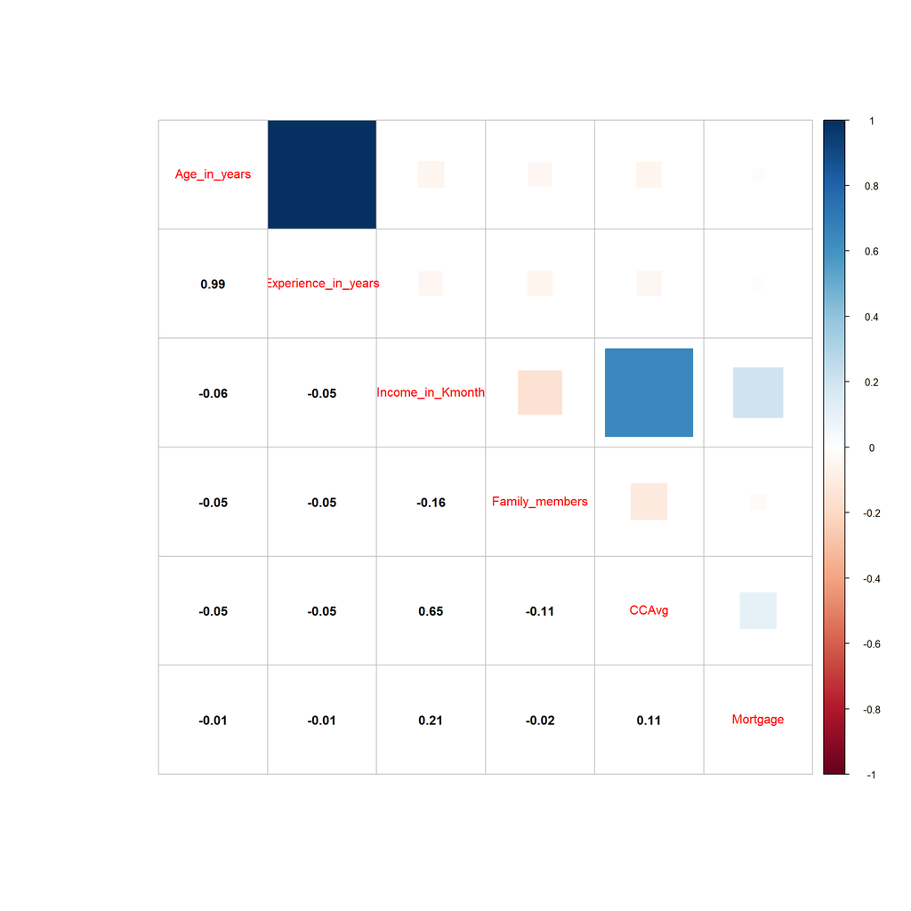

```r
cormatrix <- cor(Thera_Bank_ohe[,numeric_variables, with = FALSE])
corrplot.mixed(cormatrix, upper ='square', lower.col = 'black')
```

When looking at correlations between numeric variables, we can see that the strongest correlation between independent variables is Age and Experience. There is also a positive correlation between income and average spending on credit cards per month.

```r
table(Thera_Bank$Personal_Loan, Thera_Bank$Education)
```

```
##
##        1    2    3
##   0 2003 1221 1296
##   1   93  182  205
```

Most of the people who took the loan have graduate or higher education.

```r
table(Thera_Bank$Personal_Loan, Thera_Bank$Securities_Account)
```

```
##
##        0    1
##   0 4058  462
##   1  420   60
```

Most of the people who took the loan don’t have a securities account.

```r
table(Thera_Bank$Personal_Loan, Thera_Bank$CD_Account)
```

```
##
##        0    1
##   0 4358  162
##   1  340  140
```

Most of the people who took the loan don’t have a CD Account.

```r
table(Thera_Bank$Personal_Loan, Thera_Bank$Online)
```

```
##
##        0    1
##   0 1827 2693
##   1  189  291
```

Most of the people who took the loan use internet banking.

```r
table(Thera_Bank$Personal_Loan, Thera_Bank$CreditCard)
```

```
##
##        0    1
##   0 3193 1327
##   1  337  143
```

For factor analysis, we first need to define the number of factors to use. One way to do this is by using Psych package:

```r
Thera_Bank_fa <- scale(Thera_Bank_ohe[,numeric_variables, with = FALSE])
Parallel <- fa.parallel(Thera_Bank_fa, fm = 'minres', fa = 'fa')
```

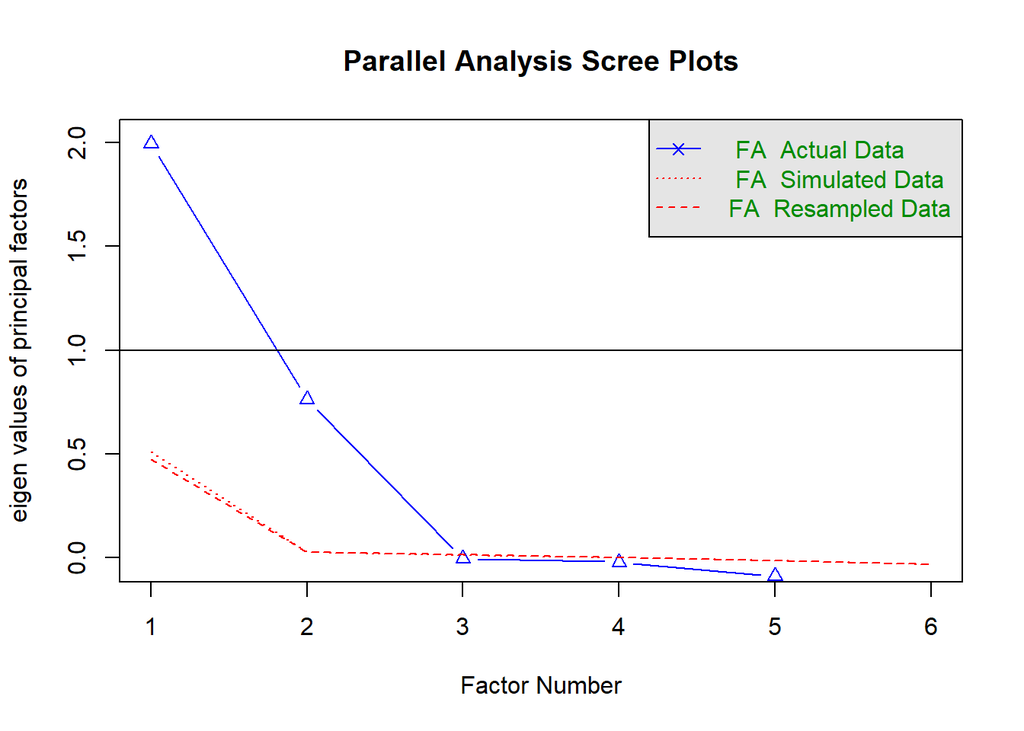

```
## Parallel analysis suggests that the number of factors =  2  and the number of components =  NA
```

Point inflection where the gap between simulated data and actual data tends to be minimum happens on 2 factors.

We run the factor analysis with 2 factors and use oblimin as rotations since we believe that there is correlation in the factors.

```r
FA <- fa(Thera_Bank_fa,nfactors = 2,rotate = "oblimin",fm="minres")
print(FA)
```

```
## Factor Analysis using method =  minres
## Call: fa(r = Thera_Bank_fa, nfactors = 2, rotate = "oblimin", fm = "minres")
## Standardized loadings (pattern matrix) based upon correlation matrix
##                       MR1   MR2    h2     u2 com
## Age_in_years         1.00  0.00 0.993 0.0074 1.0
## Experience_in_years  1.00  0.00 0.995 0.0046 1.0
## Income_in_Kmonth     0.00  1.00 0.998 0.0020 1.0
## Family_members      -0.06 -0.16 0.029 0.9710 1.2
## CCAvg               -0.02  0.64 0.416 0.5839 1.0
## Mortgage             0.00  0.19 0.038 0.9620 1.0
##
##                        MR1  MR2
## SS loadings           1.99 1.48
## Proportion Var        0.33 0.25
## Cumulative Var        0.33 0.58
## Proportion Explained  0.57 0.43
## Cumulative Proportion 0.57 1.00
##
##  With factor correlations of
##       MR1   MR2
## MR1  1.00 -0.06
## MR2 -0.06  1.00
##
## Mean item complexity =  1
## Test of the hypothesis that 2 factors are sufficient.
##
## The degrees of freedom for the null model are  15  and the objective function was  5.09 with Chi Square of  25441.31
## The degrees of freedom for the model are 4  and the objective function was  0.01
##
## The root mean square of the residuals (RMSR) is  0.01
## The df corrected root mean square of the residuals is  0.01
##
## The harmonic number of observations is  5000 with the empirical chi square  6.05  with prob <  0.2
## The total number of observations was  5000  with Likelihood Chi Square =  30.75  with prob <  3.4e-06
##
## Tucker Lewis Index of factoring reliability =  0.996
## RMSEA index =  0.037  and the 90 % confidence intervals are  0.025 0.049
## BIC =  -3.32
## Fit based upon off diagonal values = 1
## Measures of factor score adequacy
##                                                    MR1 MR2
## Correlation of (regression) scores with factors   1.00   1
## Multiple R square of scores with factors          1.00   1
## Minimum correlation of possible factor scores     0.99   1
```

Now we need to consider the loadings more than 0.5 and not loading on more than one factor:

```r
print(FA$loadings,cutoff = 0.5)
```

```
##
## Loadings:
##                     MR1    MR2
## Age_in_years         0.996
## Experience_in_years  0.998
## Income_in_Kmonth            0.999
## Family_members
## CCAvg                       0.644
## Mortgage
##
##                  MR1   MR2
## SS loadings    1.992 1.478
## Proportion Var 0.332 0.246
## Cumulative Var 0.332 0.578
```

From the above, we can see that Family_members and Mortgage have become insignificant and that there is no double loading. We also see that Age in years and Experience in years can be grouped together since they have a very strong positive correlation. We also see that Income is correlated to CCAvg to a lesser extent but there is still a strong relationship between the two.

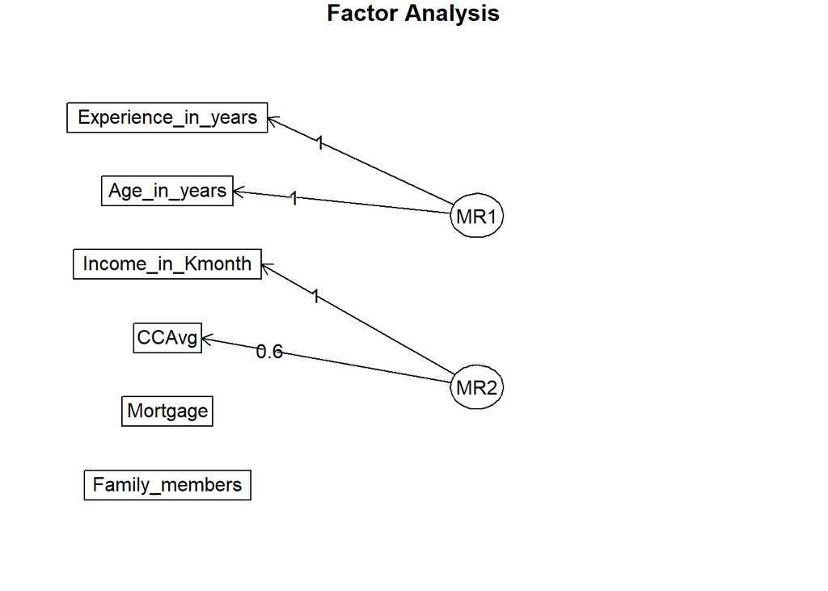

```r
fa.diagram(FA)
```

The root mean square of residuals (RMSR) is 0.01 which is acceptable since it’s very close to 0. RMSEA (root mean square error of approximation) index is 0.037 showing an ok model fit as it’s below 0.1 and cloase to 0.05. Finally, the Tucker-Lewis Index (TLI) is 0.996 – an acceptable value considering it’s over 0.9.

Looking at the 2 factors created, we will proceed to add them to the data and rename them

```r
Thera_Bank_ohe <- cbind(Thera_Bank_ohe, FA$scores)
setnames(Thera_Bank_ohe, c('MR1', 'MR2') ,c('Exp', 'P_Finance'))
head(Thera_Bank_ohe,2)
```

| Personal_Loan | Age_in_years | Experience_in_years | Income_in_Kmonth | Family_members | CCAvg | Education.1 | Education.2 | Education.3 | Mortgage | Securities_Account.0 | Securities_Account.1 | CD_Account.0 | CD_Account.1 | Online.0 | Online.1 | CreditCard.0 | CreditCard.1 | Exp | P_Finance |
| --- | --- | --- | --- | --- | --- | --- | --- | --- | --- | --- | --- | --- | --- | --- | --- | --- | --- | --- | --- |
| 0 | 25 | 1 | 49 | 4 | 1.6 | 1 | 0 | 0 | 0 | 0 | 1 | 1 | 0 | 1 | 0 | 1 | 0 | -1.70888580 | -0.5390392 |
| 0 | 45 | 19 | 34 | 3 | 1.5 | 1 | 0 | 0 | 0 | 0 | 1 | 1 | 0 | 1 | 0 | 1 | 0 | -0.07063983 | -0.8548730 |

### 3. Clustering

#### 3.1 Kmeans Clustering

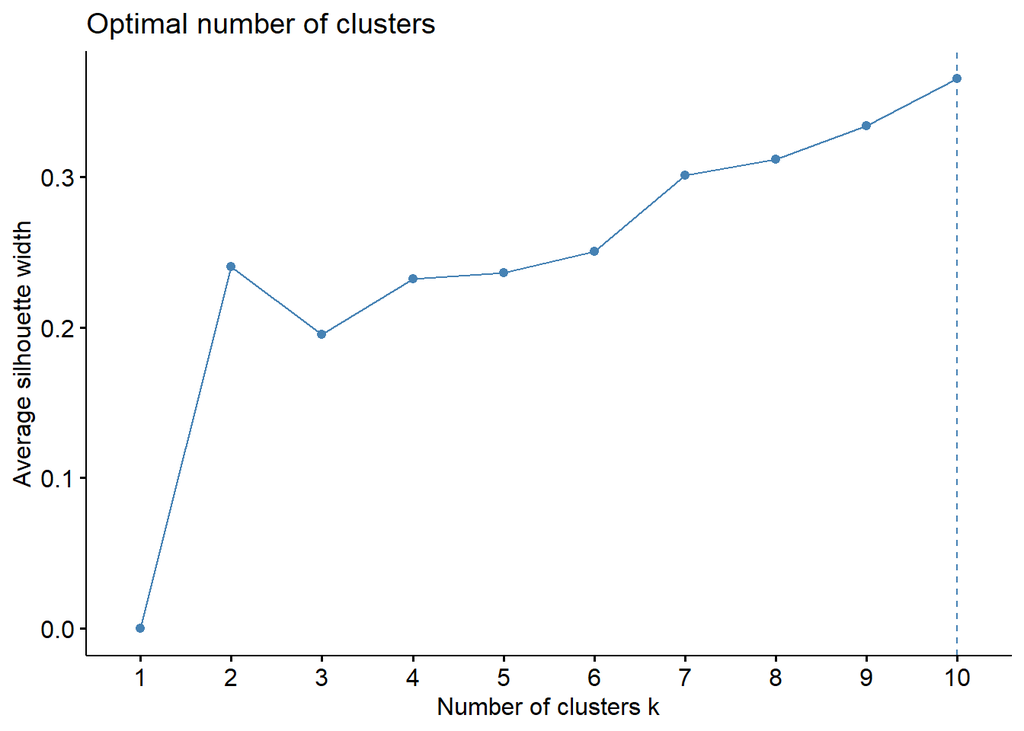

```r
set.seed(1000)
Thera_Bank_scaled <- scale(Thera_Bank_ohe[,c(7,8,9,11,12,13,14,15,16,17,18,19,20)])

fviz_nbclust(Thera_Bank_scaled, kmeans, method='silhouette')
```

Kmeans Clustering works with numeric data because it uses distance between observations to determine if they are similar or not. Because of this, the first step is to select numeric data from the table and scale it. We then run different centers to determine what the best number of clusters is for this data set. function above is used to run the silhouette method to determine the ideal number of clusters.

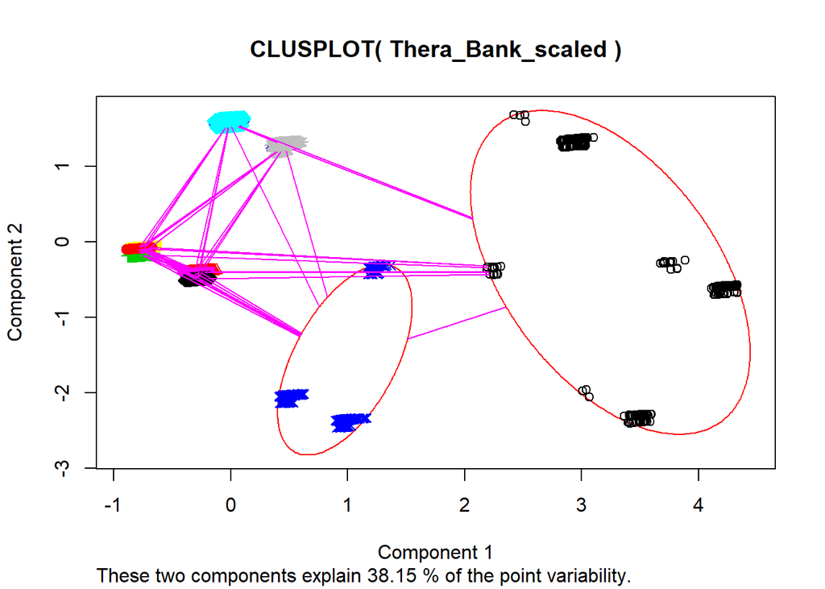

```r
Kmeans_clusters <- kmeans(Thera_Bank_scaled, centers = 10, nstart = 5)
clusplot(Thera_Bank_scaled, Kmeans_clusters$cluster, color=TRUE, shade=FALSE, labels = 0, col.p = Kmeans_clusters$cluster, stand = TRUE)
```

We assign the clusters to the data base and observe that the biggest cluster has 750 customers and the smallest has 302.

```r
Thera_Bank$cluster <- factor(Kmeans_clusters$cluster)
table(Thera_Bank$cluster)
```

```
##
##   1   2   3   4   5   6   7   8   9  10
## 302 750 338 375 527 562 551 658 542 395
```

```r
table(Thera_Bank$cluster, Thera_Bank$Personal_Loan)
```

```
##
##        0   1
##   1  162 140
##   2  726  24
##   3  301  37
##   4  366   9
##   5  477  50
##   6  492  70
##   7  526  25
##   8  658   0
##   9  471  71
##   10 341  54
```

#### 4 CART

Before running CART we will first split the dataset into training and testing sets.

```r
set.seed(1000)
Thera_Bank_model <- Thera_Bank[,!c("ID","ZIP_Code")]
train_sel <- sample(x = 1:nrow(Thera_Bank_model), size = round(nrow(Thera_Bank_model)*.7))
train <- Thera_Bank_model[train_sel]
test <- Thera_Bank_model[!train_sel]
```

We then proceed to run an initial CART model:

```r
set.seed(1000)
tree <- rpart(formula = Personal_Loan ~ ., data = train, method = "class", cp=0, minbucket=3)
tree
```

```
## n= 3500
##
## node), split, n, loss, yval, (yprob)
##       * denotes terminal node
##
##   1) root 3500 342 0 (0.902285714 0.097714286)
##     2) Income_in_Kmonth< 113.5 2810  62 0 (0.977935943 0.022064057)
##       4) CCAvg< 2.95 2595  10 0 (0.996146435 0.003853565)
##         8) Income_in_Kmonth< 106.5 2523   0 0 (1.000000000 0.000000000) *
##         9) Income_in_Kmonth>=106.5 72  10 0 (0.861111111 0.138888889)
##          18) cluster=2,3,4,5,6,7,8 60   5 0 (0.916666667 0.083333333)
##            36) cluster=2,3,5,8 31   0 0 (1.000000000 0.000000000) *
##            37) cluster=4,6,7 29   5 0 (0.827586207 0.172413793)
##              74) Family_members< 1.5 10   0 0 (1.000000000 0.000000000) *
##              75) Family_members>=1.5 19   5 0 (0.736842105 0.263157895)
##               150) Age_in_years< 33 6   0 0 (1.000000000 0.000000000) *
##               151) Age_in_years>=33 13   5 0 (0.615384615 0.384615385)
##                 302) Age_in_years>=37 10   2 0 (0.800000000 0.200000000) *
##                 303) Age_in_years< 37 3   0 1 (0.000000000 1.000000000) *
##          19) cluster=1,9,10 12   5 0 (0.583333333 0.416666667)
##            38) CCAvg>=1.3 9   2 0 (0.777777778 0.222222222)
##              76) Age_in_years>=30.5 6   0 0 (1.000000000 0.000000000) *
##              77) Age_in_years< 30.5 3   1 1 (0.333333333 0.666666667) *
##            39) CCAvg< 1.3 3   0 1 (0.000000000 1.000000000) *
##       5) CCAvg>=2.95 215  52 0 (0.758139535 0.241860465)
##        10) cluster=2,4,5,6,7,8,9,10 191  35 0 (0.816753927 0.183246073)
##          20) cluster=2,4,8 74   3 0 (0.959459459 0.040540541) *
##          21) cluster=5,6,7,9,10 117  32 0 (0.726495726 0.273504274)
##            42) Income_in_Kmonth< 92 71  10 0 (0.859154930 0.140845070)
##              84) CCAvg>=3.5 44   2 0 (0.954545455 0.045454545) *
##              85) CCAvg< 3.5 27   8 0 (0.703703704 0.296296296)
##               170) Income_in_Kmonth< 82.5 20   4 0 (0.800000000 0.200000000)
##                 340) Age_in_years>=37.5 15   1 0 (0.933333333 0.066666667) *
##                 341) Age_in_years< 37.5 5   2 1 (0.400000000 0.600000000) *
##               171) Income_in_Kmonth>=82.5 7   3 1 (0.428571429 0.571428571) *
##            43) Income_in_Kmonth>=92 46  22 0 (0.521739130 0.478260870)
##              86) Family_members< 2.5 29   7 0 (0.758620690 0.241379310)
##               172) Age_in_years< 58.5 25   4 0 (0.840000000 0.160000000)
##                 344) cluster=6,7,10 16   0 0 (1.000000000 0.000000000) *
##                 345) cluster=5,9 9   4 0 (0.555555556 0.444444444)
```

[output cut: 11 more lines]

```
##     3) Income_in_Kmonth>=113.5 690 280 0 (0.594202899 0.405797101)
##       6) Education=1 445  49 0 (0.889887640 0.110112360)
##        12) Family_members< 2.5 396   0 0 (1.000000000 0.000000000) *
##        13) Family_members>=2.5 49   0 1 (0.000000000 1.000000000) *
##       7) Education=2,3 245  14 1 (0.057142857 0.942857143)
##        14) Income_in_Kmonth< 116.5 23   9 0 (0.608695652 0.391304348)
##          28) cluster=3,4,5,6,8,9 20   6 0 (0.700000000 0.300000000)
##            56) Age_in_years>=51 7   0 0 (1.000000000 0.000000000) *
##            57) Age_in_years< 51 13   6 0 (0.538461538 0.461538462)
##             114) cluster=4,6,8,9 10   3 0 (0.700000000 0.300000000)
##               228) CCAvg< 2.25 5   0 0 (1.000000000 0.000000000) *
##               229) CCAvg>=2.25 5   2 1 (0.400000000 0.600000000) *
##             115) cluster=3,5 3   0 1 (0.000000000 1.000000000) *
##          29) cluster=10 3   0 1 (0.000000000 1.000000000) *
##        15) Income_in_Kmonth>=116.5 222   0 1 (0.000000000 1.000000000) *
```

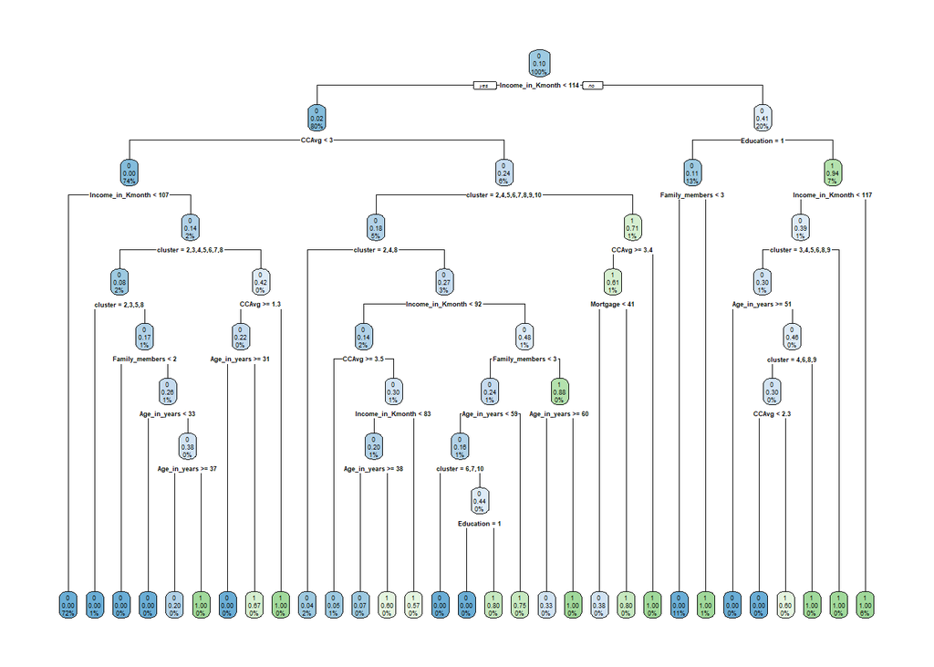

```r
rpart.plot(tree)
```

With the above tree we then obtain the complexity table to start prunning.

```r
printcp(tree)
```

```
##
## Classification tree:
## rpart(formula = Personal_Loan ~ ., data = train, method = "class",
##     cp = 0, minbucket = 3)
##
## Variables actually used in tree construction:
## [1] Age_in_years     CCAvg            cluster          Education
## [5] Family_members   Income_in_Kmonth Mortgage
##
## Root node error: 342/3500 = 0.097714
##
## n= 3500
##
##           CP nsplit rel error  xerror     xstd
## 1  0.3172515      0  1.000000 1.00000 0.051364
## 2  0.1432749      2  0.365497 0.39181 0.033193
## 3  0.0146199      3  0.222222 0.24854 0.026628
## 4  0.0126706      6  0.178363 0.24269 0.026321
## 5  0.0087719      9  0.140351 0.20760 0.024387
## 6  0.0058480     10  0.131579 0.19591 0.023704
## 7  0.0043860     11  0.125731 0.18713 0.023177
## 8  0.0029240     15  0.108187 0.19883 0.023876
## 9  0.0021930     23  0.084795 0.18713 0.023177
## 10 0.0019493     27  0.076023 0.20468 0.024218
## 11 0.0000000     30  0.070175 0.19591 0.023704
```

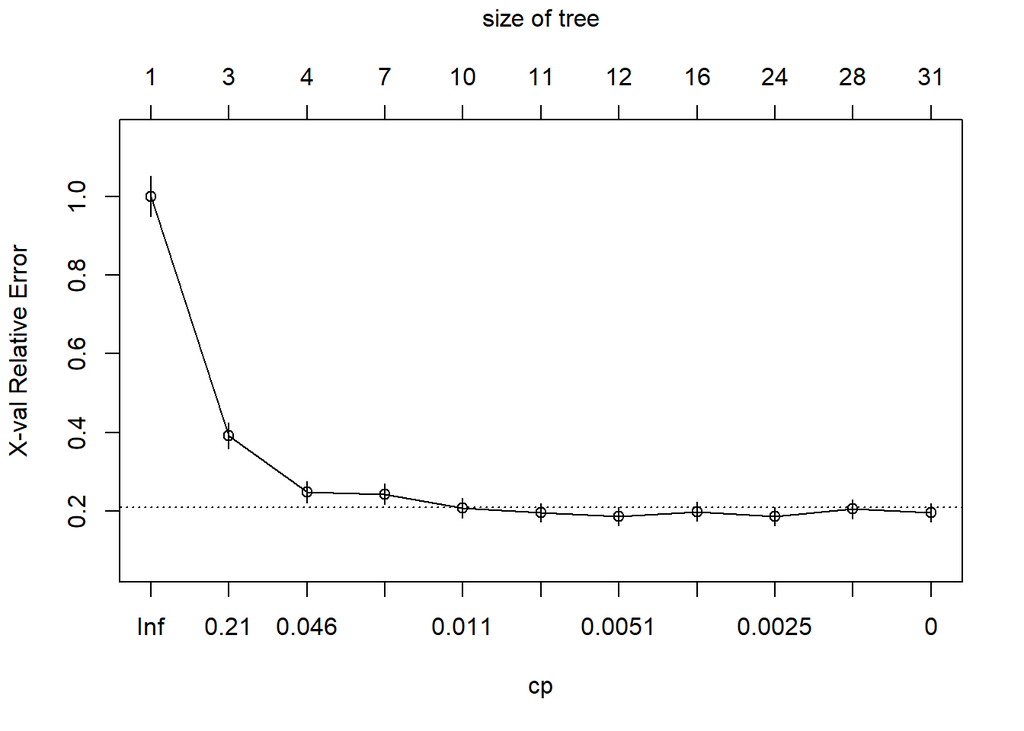

```r
plotcp(tree)
```

The above tree is then pruned. For prunning the tree, we need to define a complexity parameter which is the minimum improvement in the model needed at each node. Using a cost complexity threshold of 0.011 given by the graph above we then proceed to prune the tree.

```r
ptree = prune(tree, cp= 0.011 ,"CP")
printcp(ptree)
```

```
##
## Classification tree:
## rpart(formula = Personal_Loan ~ ., data = train, method = "class",
##     cp = 0, minbucket = 3)
##
## Variables actually used in tree construction:
## [1] CCAvg            cluster          Education        Family_members
## [5] Income_in_Kmonth
##
## Root node error: 342/3500 = 0.097714
##
## n= 3500
##
##         CP nsplit rel error  xerror     xstd
## 1 0.317251      0   1.00000 1.00000 0.051364
## 2 0.143275      2   0.36550 0.39181 0.033193
## 3 0.014620      3   0.22222 0.24854 0.026628
## 4 0.012671      6   0.17836 0.24269 0.026321
## 5 0.011000      9   0.14035 0.20760 0.024387
```

```r
ptree
```

```
## n= 3500
##
## node), split, n, loss, yval, (yprob)
##       * denotes terminal node
##
##  1) root 3500 342 0 (0.902285714 0.097714286)
##    2) Income_in_Kmonth< 113.5 2810  62 0 (0.977935943 0.022064057)
##      4) CCAvg< 2.95 2595  10 0 (0.996146435 0.003853565) *
##      5) CCAvg>=2.95 215  52 0 (0.758139535 0.241860465)
##       10) cluster=2,4,5,6,7,8,9,10 191  35 0 (0.816753927 0.183246073)
##         20) cluster=2,4,8 74   3 0 (0.959459459 0.040540541) *
##         21) cluster=5,6,7,9,10 117  32 0 (0.726495726 0.273504274)
##           42) Income_in_Kmonth< 92 71  10 0 (0.859154930 0.140845070) *
##           43) Income_in_Kmonth>=92 46  22 0 (0.521739130 0.478260870)
##             86) Family_members< 2.5 29   7 0 (0.758620690 0.241379310) *
##             87) Family_members>=2.5 17   2 1 (0.117647059 0.882352941) *
##       11) cluster=1,3 24   7 1 (0.291666667 0.708333333) *
##    3) Income_in_Kmonth>=113.5 690 280 0 (0.594202899 0.405797101)
##      6) Education=1 445  49 0 (0.889887640 0.110112360)
##       12) Family_members< 2.5 396   0 0 (1.000000000 0.000000000) *
##       13) Family_members>=2.5 49   0 1 (0.000000000 1.000000000) *
##      7) Education=2,3 245  14 1 (0.057142857 0.942857143)
##       14) Income_in_Kmonth< 116.5 23   9 0 (0.608695652 0.391304348) *
##       15) Income_in_Kmonth>=116.5 222   0 1 (0.000000000 1.000000000) *
```

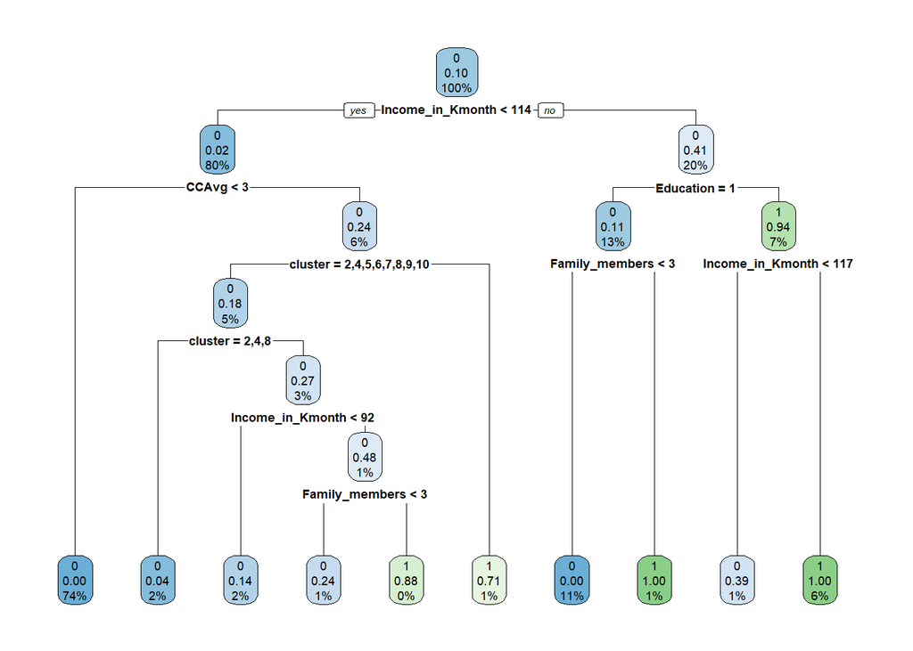

```r
rpart.plot(ptree)
```

It seems like the CART model is giving importance to the Income information as well as Education, Family member, CCAvg and finally the clusters created in above steps.

The next step is to test the model on train and test data:

```r
train$prediction = predict(ptree, newdata= train, type="class")
tbl <- table(train$Personal_Loan, train$prediction)
print(tbl)
```

```
##
##        0    1
##   0 3149    9
##   1   39  303
```

```r
print((tbl[1,2]+tbl[2,1])/nrow(train))
```

```
## [1] 0.01371429
```

```r
print((tbl[1,1]+tbl[2,2])/(nrow(train)))
```

```
## [1] 0.9862857
```

```r
print((tbl[2,2])/(tbl[2,1]+tbl[2,2]))
```

```
## [1] 0.8859649
```

Model seems to perform reasonably well on predicting people who said yes to the loan (True positives). Out of 342 people in the train dataset who said yes to the loan, the model predicted 303 correctly. The model also did a good job in predicting people who chose not to take the offer (True negatives), out of 3158 customers who said no, the model was able to predict 3149.

```r
test$prediction = predict(ptree, newdata= test, type="class")

tbl <- table(test$Personal_Loan, test$prediction)
print(tbl)
```

```
##
##        0    1
##   0 1357    5
##   1   17  121
```

```r
print((tbl[1,2]+tbl[2,1])/nrow(test))
```

```
## [1] 0.01466667
```

```r
print((tbl[1,1]+tbl[2,2])/(nrow(test)))
```

```
## [1] 0.9853333
```

```r
print((tbl[2,2])/(tbl[2,1]+tbl[2,2]))
```

```
## [1] 0.8768116
```

Test model also seems to yield good results. Out of 138 people in the test dataset who said yes to the loan, the model predicted 121 correctly. The model also did a good job in predicting people who chose not to take the offer, out of 1362 customers who said no, the model was able to predict 1357

#### 4 Random Forest

The above CART results are encouraging and it means that we are in the right track to be able to identify future customers that will be more likely to accept a loan offer given the past experience with previous campaigns.

To improve the robustness of the model, the next step is to train a random forest model which is similar to creating a model from several independent “tree” models until we have a forest. This way, we make the model stronger by trining it with different iterations of data and prepare it so it behaves better when unseen data is fed into the model.

```r
train$prediction <- NULL
test$prediction <- NULL

set.seed(1000)
rndFor = randomForest(Personal_Loan ~ ., data = train, ntree = round(0.2*nrow(train)), mtry = round(sqrt(length(train)-1)), nodesize = 10,importance=TRUE)
print(rndFor)
```

```
##
## Call:
##  randomForest(formula = Personal_Loan ~ ., data = train, ntree = round(0.2 *      nrow(train)), mtry = round(sqrt(length(train) - 1)), nodesize = 10,      importance = TRUE)
##                Type of random forest: classification
##                      Number of trees: 700
## No. of variables tried at each split: 3
##
##         OOB estimate of  error rate: 1.51%
## Confusion matrix:
##      0   1 class.error
## 0 3150   8 0.002533249
## 1   45 297 0.131578947
```

We first start by creating a model with temporary parameters. For ntree we use 20% of the observations in the train dataset and for the mtry we use sqrt of the number of variables.

```r
head(rndFor$err.rate,100)
```

```
##               OOB           0         1
##   [1,] 0.05955143 0.036815068 0.2720000
##   [2,] 0.04636711 0.023872679 0.2512077
##   [3,] 0.04158718 0.019417476 0.2500000
##   [4,] 0.03443619 0.014981273 0.2123288
##   [5,] 0.03317536 0.013674614 0.2108626
##   [6,] 0.03313070 0.012137559 0.2253086
##   [7,] 0.03271862 0.014177382 0.2036474
##   [8,] 0.02870533 0.011695906 0.1845238
##   [9,] 0.02756020 0.009974260 0.1887906
##  [10,] 0.02740912 0.010236724 0.1852941
##  [11,] 0.02500000 0.007648184 0.1842105
##  [12,] 0.02151463 0.006997455 0.1549708
##  [13,] 0.02034967 0.006037496 0.1520468
##  [14,] 0.01860865 0.005395113 0.1403509
```

[output cut: 86 more lines]

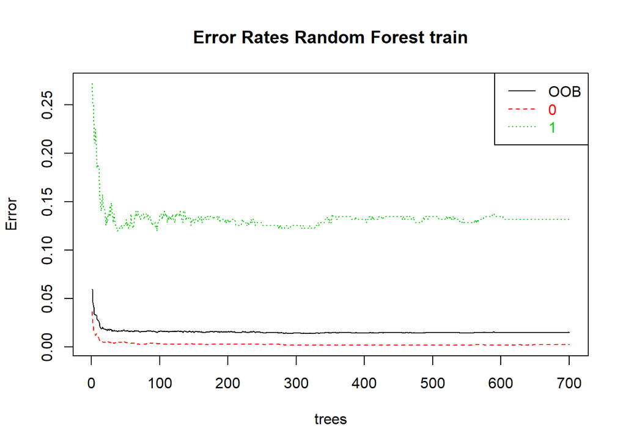

```r
plot(rndFor, main="")
legend("topright", c("OOB", "0", "1"), text.col=1:6, lty=1:3, col=1:3)
title(main="Error Rates Random Forest train")
```

```r
rndFor$importance
```

```
##                                0             1 MeanDecreaseAccuracy
## Age_in_years        0.0046954878  0.0023067750         0.0044677341
## Experience_in_years 0.0042974543  0.0027767361         0.0041515439
## Income_in_Kmonth    0.1033277440  0.3865982825         0.1309757048
## Family_members      0.0383230464  0.0513304311         0.0395849859
## CCAvg               0.0310741911  0.0810083813         0.0359364512
## Education           0.0441891297  0.0924361074         0.0489196845
## Mortgage            0.0025911233 -0.0009860233         0.0022405411
## Securities_Account  0.0002832451  0.0011864586         0.0003713096
## CD_Account          0.0035696926  0.0089843378         0.0041034226
## Online              0.0015607217  0.0026387326         0.0016693957
## CreditCard          0.0026076909  0.0037294694         0.0027247206
## cluster             0.0210948269  0.0809067830         0.0269451507
##                     MeanDecreaseGini
## Age_in_years               11.942398
## Experience_in_years        11.829104
## Income_in_Kmonth          184.396344
## Family_members             54.505408
## CCAvg                      84.705822
## Education                  75.187598
## Mortgage                   14.528344
## Securities_Account          1.319856
## CD_Account                 18.643813
## Online                      2.119834
## CreditCard                  3.347665
## cluster                    81.136779
```

Next step is to “tune” the Random Forest by trying different m values.

```
## mtry = 3  OOB error = 1.51%
## Searching left ...
## mtry = 2     OOB error = 1.86%
## -0.2264151 1e-04
## Searching right ...
## mtry = 4     OOB error = 1.49%
## 0.01886792 1e-04
## mtry = 6     OOB error = 1.51%
## -0.01923077 1e-04
```

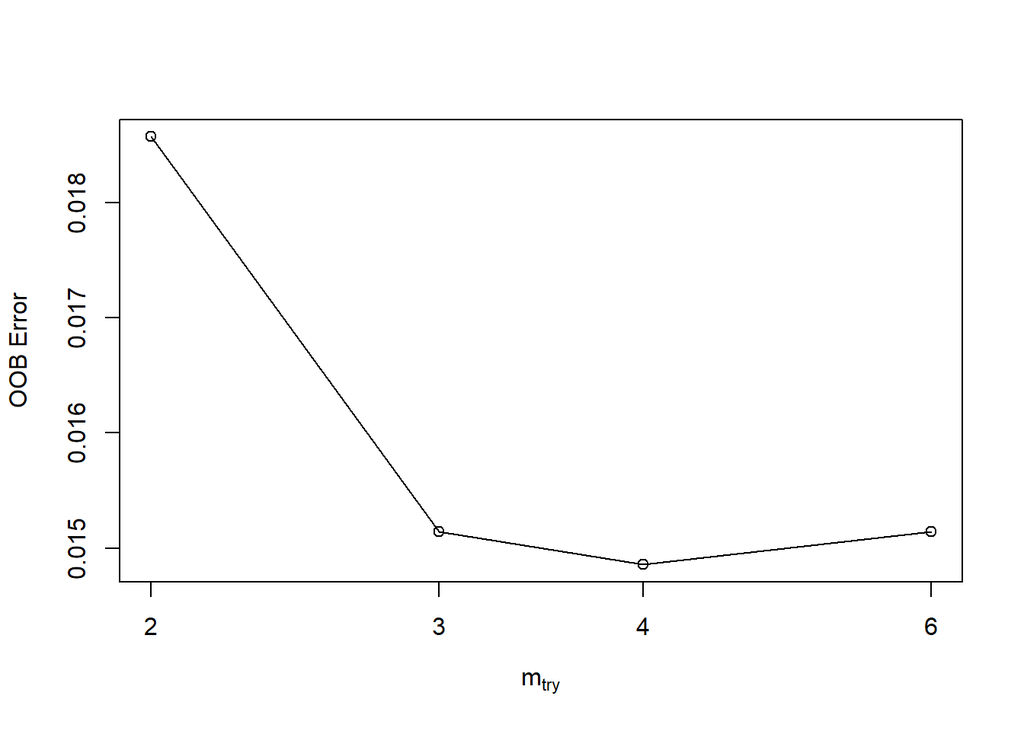

```r
set.seed(1000)
tRndFor = tuneRF(x = train[,!("Personal_Loan")],
              y=train$Personal_Loan,
              mtryStart = 3,
              ntreeTry = 501,
              stepFactor = 1.5,
              improve = 0.0001,
              trace=TRUE,
              plot = TRUE,
              doBest = TRUE,
              nodesize = 10,
              importance=TRUE
)
```

```r
importance(tRndFor)
```

```
##                              0          1 MeanDecreaseAccuracy
## Age_in_years         10.134455  0.2291983            10.251863
## Experience_in_years  10.540769  1.6240419            10.736780
## Income_in_Kmonth    109.248372 82.1060644           122.856313
## Family_members       72.659221 42.2173111            73.362832
## CCAvg                30.454458 31.1519384            34.364484
## Education            43.161612 39.7938981            46.330609
## Mortgage              9.805504 -2.6913917             8.510582
## Securities_Account    3.419847 -0.5816970             2.367936
## CD_Account           11.239983  5.0053536            12.184521
## Online                6.007619  2.6266196             7.178089
## CreditCard            9.830962  1.4062172             8.798822
## cluster              21.452747 24.2068348            26.124269
##                     MeanDecreaseGini
## Age_in_years              10.5704121
## Experience_in_years       11.4305026
## Income_in_Kmonth         185.9929851
## Family_members            61.6811928
## CCAvg                     82.2362187
## Education                 93.5780898
## Mortgage                  10.5449082
## Securities_Account         0.9876506
## CD_Account                16.6237759
## Online                     1.4445538
## CreditCard                 2.9995737
## cluster                   79.4153740
```

```r
print(tRndFor)
```

```
##
## Call:
##  randomForest(x = x, y = y, mtry = res[which.min(res[, 2]), 1],      nodesize = 10, importance = TRUE)
##                Type of random forest: classification
##                      Number of trees: 500
## No. of variables tried at each split: 4
##
##         OOB estimate of  error rate: 1.57%
## Confusion matrix:
##      0   1 class.error
## 0 3150   8 0.002533249
## 1   47 295 0.137426901
```

```r
## Scoring syntax
train$predict.class = predict(tRndFor, train, type="class")
train$prob1 = predict(tRndFor, train, type="prob")[,"1"]

tbl <- table(train$Personal_Loan, train$predict.class)
print(tbl)
```

```
##
##        0    1
##   0 3158    0
##   1   22  320
```

```r
print((tbl[1,2]+tbl[2,1])/nrow(train))
```

```
## [1] 0.006285714
```

```r
print((tbl[1,1]+tbl[2,2])/(nrow(train)))
```

```
## [1] 0.9937143
```

```r
print((tbl[2,2])/(tbl[2,1]+tbl[2,2]))
```

```
## [1] 0.9356725
```

```r
## Scoring syntax
test$predict.class = predict(tRndFor, test, type="class")
test$prob1 = predict(tRndFor, test, type="prob")[,"1"]
tbl <- table(test$Personal_Loan, test$predict.class)
print(tbl)
```

```
##
##        0    1
##   0 1358    4
##   1   15  123
```

```r
print((tbl[1,2]+tbl[2,1])/nrow(test))
```

```
## [1] 0.01266667
```

```r
print((tbl[1,1]+tbl[2,2])/(nrow(test)))
```

```
## [1] 0.9873333
```

```r
print((tbl[2,2])/(tbl[2,1]+tbl[2,2]))
```

```
## [1] 0.8913043
```

Test data set also yields good results and are in line with the train data which means there is no overfitting.

Overall, the model proves to be useful in clearly identifying those customers who will not acquire the loan and it also does a good job in selecting customers who will acquire it.

I would look for two particular customer profiles described below:

```r
## Scoring syntax
cust_1 <- Thera_Bank[Income_in_Kmonth > 117 & Education != 1]
summary(cust_1[,.(Income_in_Kmonth, CCAvg)])
```

```
##  Income_in_Kmonth     CCAvg
##  Min.   :118.0    Min.   : 0.00
##  1st Qu.:134.0    1st Qu.: 2.60
##  Median :158.0    Median : 4.10
##  Mean   :157.1    Mean   : 4.14
##  3rd Qu.:179.0    3rd Qu.: 5.80
##  Max.   :203.0    Max.   :10.00
```

+cust_1 : Customers with annual income grerater than 117,000 and who have graduate degree or higher.

```r
## Scoring syntax
cust_2 <- Thera_Bank[Income_in_Kmonth > 114 & Education == 1 & Family_members >3]
summary(cust_2[,.(Income_in_Kmonth, CCAvg, Education, Family_members)])
```

```
##  Income_in_Kmonth     CCAvg       Education Family_members
##  Min.   :120.0    Min.   :0.200   1:30      Min.   :4
##  1st Qu.:133.2    1st Qu.:1.425   2: 0      1st Qu.:4
##  Median :145.0    Median :4.025   3: 0      Median :4
##  Mean   :149.3    Mean   :3.553             Mean   :4
##  3rd Qu.:168.0    3rd Qu.:5.400             3rd Qu.:4
##  Max.   :195.0    Max.   :6.900             Max.   :4
```

Similar to customer 1. The difference is that these customers have an undergraduate degree and families with at least 4 members.

```r
## Scoring syntax
cust_3 <- Thera_Bank[Income_in_Kmonth <= 114 & CCAvg >= 3 & !(cluster %in% c(2,4:10))]
summary(cust_2[,.(Income_in_Kmonth, CCAvg, Education, Family_members)])
```

```
##  Income_in_Kmonth     CCAvg       Education Family_members
##  Min.   :120.0    Min.   :0.200   1:30      Min.   :4
##  1st Qu.:133.2    1st Qu.:1.425   2: 0      1st Qu.:4
##  Median :145.0    Median :4.025   3: 0      Median :4
##  Mean   :149.3    Mean   :3.553             Mean   :4
##  3rd Qu.:168.0    3rd Qu.:5.400             3rd Qu.:4
##  Max.   :195.0    Max.   :6.900             Max.   :4
```

There is another potential group of customers but they don’t seem to be that many in the sample set. My initial recommendation would be to target customer groups 1 and 2 highlighted above.